# Задание к лекции №6

**Тема**: Введение в статистический анализ данных

```python
# Подготовка зависимостей
import numpy as np
import pandas as pd
import matplotlib.pyplot as plt
import seaborn as sns
from scipy import stats
```

Ответить на вопросы и прикрепить на проверку:

1. Что такое статистика? Примеры использования статистики в реальной жизни.

**Ответ**: Статистика — это набор математических процедур, которые необходимы для организации, обобщения и интерпретации информации.

Примеры использования статистики в реальной жизни (из лекции):

- Средняя заработная плата по стране за 2020 год.
- Общее количество осадков, выпавших в центральном регионе за лето 2021 года.
- Средний балл выпускников — позволяет оценить уровень образования в школе.
- Минимальная цена аренды за последний месяц — позволяет понять, можно ли позволить себе аренду квартиры в определённом районе.
- Сбор информации о количестве кликов по рекламным баннерам — чтобы понять, какой баннер лучше привлекает пользователей.
- Опрос студентов о количестве часов подготовки и полученной оценке — чтобы понять, как оценка за экзамен зависит от количества часов подготовки.
2. Типы признаков: количественные и качественные.

**Ответ**: Данные бывают трёх типов. Глобально они делятся на две группы: **количественные** и **качественные**. Могут встречаться и другие названия: например, качественные называют категориальными.

**Количественные данные** выражаются числами. Причём важно отметить, что числа имеют математическое значение. Например, вес, рост или зарплата. Количественные данные можно сравнивать друг с другом. Можно сказать, что зарплата в 50000 будет на 10000 больше, чем зарплата в 40000. Или что вес 90 кг в полтора раза больше, чем вес 60 кг.

**Качественные данные** бывают двух типов: порядковые (их ещё называют ординальными) и номинальные. Оба типа отражают принадлежность к категориям. Порядковые данные можно упорядочить, а номинальные — нет.

Важно отметить, что несмотря на то, что в качественных признаках не фигурируют числа, они могут быть закодированы через них. Однако здесь эти числа не имеют математического значения, поэтому данные не являются количественными.

3. Количественные данные: интервальные данные и данные, измеренные по шкале отношений. Привести по 2-3 примера на каждый подтип.

**Ответ**: Выделяют два подтипа количественных данных: **интервальные данные** и **данные, измеренные по шкале отношений**. Основным аспектом, который отличает эти два вида, является наличие нуля в шкале измерений.

**Интервальные данные:** нулевое значение существует просто для удобства вычислений и выбирается произвольно. Мы можем вычитать или складывать данные, но не можем их умножать или делить.

Примеры из лекции:

1. Температура по шкале Цельсия
2. Температура по шкале Фаренгейта

(В лекции приведены только эти примеры для интервальных данных.)

**Данные, измеренные по шкале отношений:** ноль имеет содержательный смысл, и его значение фиксированное. С такими данными можно производить любые арифметические действия.

Примеры из лекции:

1. Количество воды в бутылке (ноль — отсутствие воды)
2. Зарплата (упоминается в лекции как пример количественных данных)
3. Вес (упоминается в лекции как пример количественных данных)
4. Количественные данные: непрерывные и дискретные. Привести по 2-3 примера на каждый подтип.

**Ответ**: Количественные данные также можно разделить на две подгруппы: **непрерывные** и **дискретные**.

**Дискретные данные** измеряются определённым, счётным набором значений (количество таких возможных значений ограничено).

Примеры из лекции:

1. Количество людей в комнате (может быть равно 5, 7, 25 или даже 100)
2. Число бракованных изделий на линии
3. Результаты футбольного матча

**Непрерывные данные** могут принимать абсолютно любое значение из какого-то интервала (на промежутке чисел может быть бесконечное количество возможных значений).

Примеры из лекции:

1. Длина
2. Цена доллара
3. Убытки при наступлении страхового случая
5. Качественные данные: порядковые и номинальные. Привести по 2-3 примера на каждый подтип.

**Ответ**: Качественные данные бывают двух типов: **порядковые** (их ещё называют ординальными) и **номинальные**. Оба типа отражают принадлежность к категориям. Однако есть фундаментальное отличие: порядковые данные можно упорядочить, а номинальные — нет.

**Порядковые данные** (примеры из лекции):

1. Степень ожога — всегда можно однозначно упорядочить, какой ожог сильнее, а какой — слабее.
2. Спортивный разряд — очевидно, что мастер спорта «больше», чем человек с первым юношеским разрядом.
3. Уровень образования — кандидат наук будет «выше» в данной иерархии, чем человек со средним специальным образованием.

**Номинальные данные** (примеры из лекции):

1. Группа крови — нельзя сказать, что первая группа крови «больше» или «меньше», чем вторая или четвёртая.
2. Пол — нельзя упорядочить мужчин и женщин и сказать, что кто-то лучше или «больше».
6. Что такое генеральная совокупность? Привести пример.

**Ответ**: **Генеральная совокупность** — это совокупность всех объектов, которые представляют интерес в конкретном исследовании.

Примеры из лекции:

- Если вы хотите узнать, как женщины старше 18 в России относятся к новой рекламе какого-либо продукта, то генеральной совокупностью будут абсолютно все женщины, проживающие в России, чей возраст превышает 18 лет.
- Если вам интересен прогресс в обучении у первоклассников, то генеральной совокупностью будут абсолютно все дети, которые обучаются в школе первый год.
7. Что такое выборка? Привести пример.

**Ответ**: **Выборка** — это группа объектов, отобранных из генеральной совокупности для исследования.

Из генеральной совокупности отбирается только часть объектов (выборка), проводится на них исследование, а получившиеся результаты обобщаются на всю генеральную совокупность.

Пример из лекции: есть 1000 школьников, которые сдали ЕГЭ — это генеральная совокупность. Из этой группы выбираются две выборки по 5 человек.

8. Репрезентативность выборки. Смещение.

**Ответ**: **Репрезентативность** — соответствие характеристик выборки характеристикам генеральной совокупности.

Для того чтобы было выполнено условие репрезентативности, все основные особенности исследуемой группы людей или объектов должны быть одни и те же у выборки и у генеральной совокупности. Например, если в генеральной совокупности 40% женщин и 60% мужчин, то и в выборке должно быть такое же соотношение. При соблюдении процедуры такую выборку можно, например, получить с помощью случайного выбора.

Важно понимать, что даже для репрезентативной выборки будет наблюдаться **ошибка выборки** — несоответствие между характеристиками генеральной совокупности и характеристиками, полученными для данной выборки.

**Смещение выборки** — явление, при котором статистические характеристики выборки сильно отличаются (смещены) относительно характеристик генеральной совокупности.

Причины смещения (из лекции):

1. Нерепрезентативная выборка (например, психолог изучает особенности восприятия людей в целом, но в качестве респондентов использует только своих студентов).
2. Отсутствие части данных (в социальных опросах люди могут избегать ответов на вопросы про религию, деньги и другие личные темы).
3. Явление социальной желательности (люди не склонны отвечать даже анонимно то, что не вызовет социальное одобрение).
9. Визуализация частотного распределения с помощью гистограммы, полигона и столбчатой диаграммы. Смоделировать данные и привести пример на каждый вид диаграмм.

**Ответ**: **Гистограмма** — для её построения по оси абсцисс (оси x) откладываются все возможные значения, а по оси ординат (оси y) — частоты. Гистограмму можно построить только для количественных данных.

**Полигон распределения** — необходимо отметить точки на области построения, которые соответствуют высоте столбца (как если бы строилась гистограмма). После того как все точки отмечены, их соединяют, и получается полигон. Полигон является скорее вспомогательным типом визуализации, который используется редко.

**Столбчатая диаграмма** — аналог гистограммы для качественных данных. Для её построения нужны ровно те же действия, что и для гистограммы, но визуально она немного отличается: между столбцами для разных категорий есть расстояние. Если визуализируется распределение порядкового признака, то категории обычно располагаются в упорядоченном виде: по возрастанию или убыванию. Для номинального признака значения никак нельзя упорядочить, поэтому столбцы могут располагаться в любом порядке, но чаще для простоты интерпретации их располагают от самого высокого до самого низкого.

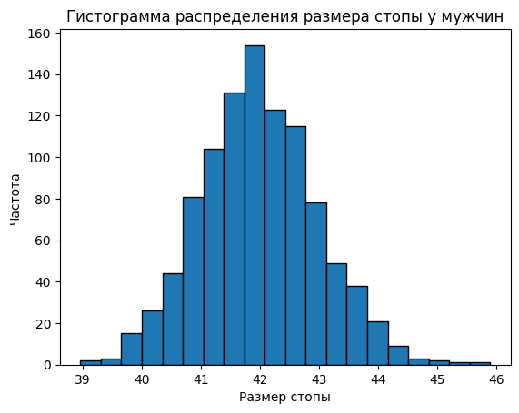

```python
plt.hist(np.random.normal(42, 1, 1000), 20, edgecolor="black")
plt.title("Гистограмма распределения размера стопы у мужчин")
plt.xlabel("Размер стопы")
plt.ylabel("Частота")
plt.show()
```

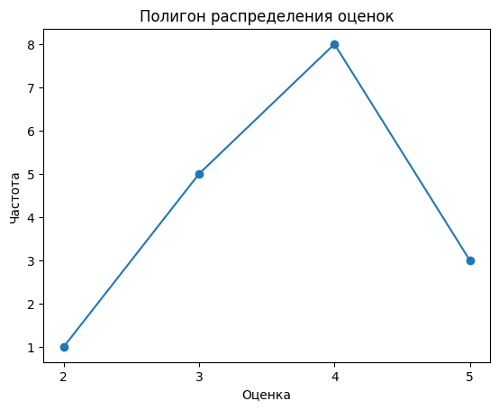

```python
plt.plot(
  [2, 3, 4, 5],
  [1, 5, 8, 3],
  marker='o'
)
plt.title('Полигон распределения оценок')
plt.xlabel('Оценка')
plt.ylabel('Частота')
plt.xticks([2, 3, 4, 5])
plt.show()
```

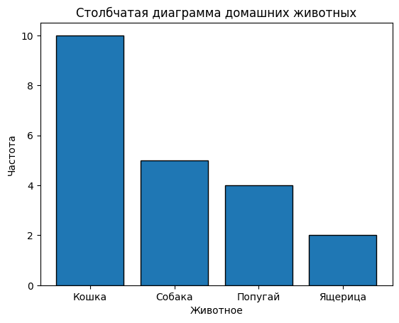

```python
plt.bar(
  ["Кошка", "Собака", "Попугай", "Ящерица"],
  [10, 5, 4, 2],
  edgecolor="black"
)
plt.title("Столбчатая диаграмма домашних животных")
plt.xlabel("Животное")
plt.ylabel("Частота")
plt.show()
```

10. Что такое случайная величина (СВ)? Привести пример дискретной и непрерывной СВ.

**Ответ**: Под **случайной величиной** понимается переменная, которая в результате испытания в зависимости от случая принимает одно из возможного множества своих значений.

**Дискретная случайная величина** — случайная величина, множество значений которой конечное, или бесконечное, но счётное.

**Непрерывная случайная величина** — случайная величина, которая может принимать любые значения из некоторого промежутка.

Пример непрерывной СВ (из лекции): цена доллара; убытки при наступлении страхового случая.

11. Что такое закон распределения СВ?

**Ответ**: **Законом распределения случайной величины** называется всякое соотношение, устанавливающее связь между возможными значениями случайной величины и соответствующими им вероятностями.

Закон распределения для дискретной случайной величины может быть задан в виде ряда распределения случайной величины — таблицы, в первой строке которой в порядке возрастания указаны возможные значения случайной величины, а во второй строке — соответствующие вероятности. При этом p_i = P(X = x_i) — вероятность события (X = x_i). Все события (X = x_i) образуют полную группу событий, поэтому сумма всех p_i равна 1.

Ряд распределения может быть изображён графически: по оси абсцисс откладывают значения случайной величины, а по оси ординат — соответствующие им вероятности. Соединение полученных точек образует ломаную, называемую многоугольником или полигоном распределения вероятности.

12. Числовые характеристики дискретных СВ.

**Ответ**: **Математическое ожидание** дискретной случайной величины — сумма произведений всех её возможных значений на соответствующие им вероятности:

M(X) = Σ x_i · p_i = x₁p₁ + x₂p₂ + … + xₙpₙ

Свойства математического ожидания:

1. M(C) = C, C — const.
2. M(kX) = k·M(X).
3. M(X ± Y) = M(X) + M(Y).
4. M(X · Y) = M(X) · M(Y), если X, Y — независимы.
5. M(X − M(X)) = 0.

**Дисперсия** случайной величины — математическое ожидание квадрата её отклонений от математического ожидания:

D(X) = M(X − M(X))²

Дисперсия может быть рассчитана по формуле:

D(X) = M(X²) − (M(X))²

Свойства дисперсии:

1. D(C) = 0, C — const.
2. D(kX) = k²·D(X).
3. D(X ± Y) = D(X) + D(Y), если X, Y — независимы.

**Среднее квадратическое отклонение (стандартное отклонение)** случайной величины — корень квадратный из её дисперсии:

σ(X) = √D(X)

**Мода** дискретной случайной величины — возможное значение случайной величины, которое имеет наибольшую соответствующую вероятность.

**Медиана** дискретной случайной величины — возможное значение случайной величины, слева и справа от которого в ряде распределения случайной величины одинаковое число значений случайной величины.

13. Функция распределения СВ, свойства.

**Ответ**: **Функцией распределения** случайной величины X называется функция F(x), выражающая для каждого события x вероятность того, что случайная величина X примет значение, меньшее x:

F(x) = P(X < x)

**Свойства функции распределения:**

1. 0 ≤ F(x) ≤ 1.
2. F(x) — монотонно не убывает: если x₂ > x₁, то F(x₂) ≥ F(x₁).
3. lim F(x) при x→−∞ = 0; lim F(x) при x→+∞ = 1.
4. P(x₁ ≤ X < x₂) = F(x₂) − F(x₁).

Случайная величина X называется непрерывной, если её функция распределения непрерывна в любой точке и дифференцируема всюду, кроме, может быть, отдельных точек.

Вероятность любого отдельно взятого значения непрерывной случайной величины равна нулю: P(X = x) = 0.

Для непрерывной случайной величины справедливо равенство:

P(x₁ ≤ X ≤ x₂) = P(x₁ ≤ X < x₂) = P(x₁ < X ≤ x₂) = P(x₁ < X < x₂)

14. Функция плотности вероятности непрерывной СВ, свойства.

**Ответ**: **Плотностью вероятности (дифференциальной функцией распределения)** непрерывной случайной величины называется производная её функции распределения:

φ(x) = F′(x)

Для непрерывной случайной величины справедливо равенство:

P(a ≤ X ≤ b) = ∫ от a до b φ(x) dx

Функция распределения непрерывной случайной величины может быть выражена через плотность вероятности по формуле:

F(x) = ∫ от −∞ до x φ(t) dt

**Свойства дифференциальной функции распределения:**

1. φ(x) ≥ 0.
2. ∫ от −∞ до +∞ φ(x) dx = 1.
15. Числовые характеристики непрерывных случайных величин.

**Ответ**: **Математическое ожидание:**

M(X) = ∫ от −∞ до +∞ x · φ(x) dx

**Дисперсия:**

D(X) = ∫ от −∞ до +∞ (x − M(X))² · φ(x) dx

16. Смоделировать 5 выборок объемом 1000 элементов из разных законов распределения: нормальное, экспоненциальное, равномерное и два любых других закона распределения на выбор (см. Генераторы распределений). Визуализировать полученные выборки, используя гистограммы и диаграммы «Ящик с усами», построить эмпирические функцию и плотность распределения. Для каждой выборки посчитать описательные характеристики (минимум и максимум, мат. ожидание, дисперсия, стандартное отклонение, квантили уровней 0.25 и 0.75, размах, медиана, коэффициенты асимметрии и эксцесса).

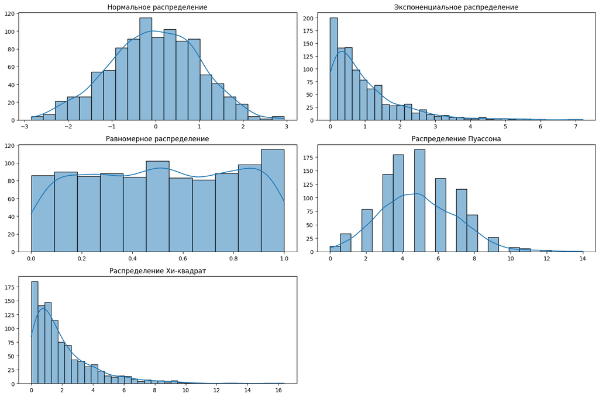

```python
np.random.seed(69)
size = 1000

# Генерация выборок
samples = {
  "Нормальное распределение": np.random.normal(loc=0, scale=1, size=size),
  "Экспоненциальное распределение": np.random.exponential(scale=1, size=size),
  "Равномерное распределение": np.random.uniform(low=0, high=1, size=size),
  "Распределение Пуассона": np.random.poisson(lam=5, size=size),
  "Распределение Хи-квадрат": np.random.chisquare(df=2, size=size),
}

# Визуализация выборок c помощью гистограмм
plt.figure(figsize=(15, 10))

for i, (name, sample) in enumerate(samples.items(), 1):
  plt.subplot(3, 2, i)
  sns.histplot(sample, kde=True)
  plt.ylabel("")
  plt.title(name)

plt.tight_layout()
plt.show()
```

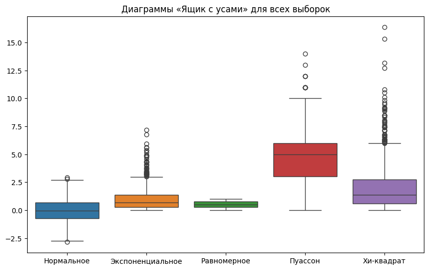

```python
# Визуализация выборок c помощью диаграммы "Ящик с усами"
plt.figure(figsize=(10, 6))

sns.boxplot(list(samples.values()))

plt.xticks(
  ticks=range(len(samples)),
  labels=["Нормальное", "Экспоненциальное", "Равномерное", "Пуассон", "Хи-квадрат"],
)
plt.title("Диаграммы «Ящик с усами» для всех выборок")
plt.show()
```

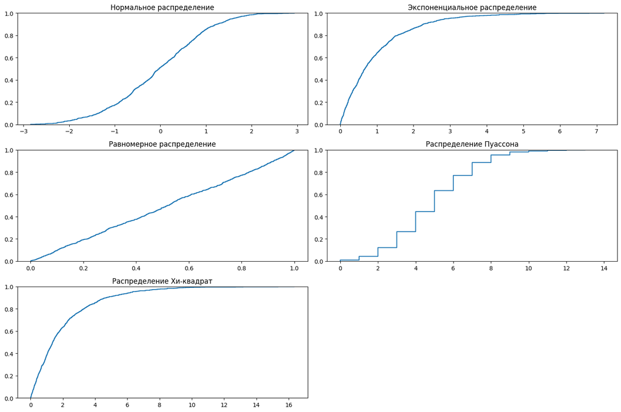

```python
# Построение эмпирических функций распределения и плотности
plt.figure(figsize=(15, 10))

for i, (name, sample) in enumerate(samples.items(), 1):
  plt.subplot(3, 2, i)
  sns.ecdfplot(sample)
  plt.ylabel("")
  plt.title(name)

plt.tight_layout()
plt.show()
```

```python
# Расчет описательных характеристик
metrics = pd.DataFrame(columns=list(samples.keys()))
for name, sample in samples.items():
  metrics[name] = {
    'Минимум':          sample.min(),
    'Максимум':         sample.max(),
    'Мат. ожидание':    sample.mean(),
    'Дисперсия':        sample.var(),
    'Стд. отклонение':  sample.std(),
    'Квантиль 0.25':    np.percentile(sample, 25),
    'Квантиль 0.75':    np.percentile(sample, 75),
    'Размах':           sample.max() - sample.min(),
    'Медиана':          np.median(sample),
    'Асимметрия':       stats.skew(sample),
    'Эксцесс':          stats.kurtosis(sample),
  }

metrics
```

|  | Нормальное распределение | Экспоненциальное распределение | Равномерное распределение | Распределение Пуассона | Распределение Хи-квадрат |
| --- | --- | --- | --- | --- | --- |
| Минимум | -2.843889 | 7.302332e-07 | 0.000235 | 0.000000 | 0.002790 |
| Максимум | 2.938285 | 7.202429e+00 | 0.999966 | 14.000000 | 16.362232 |
| Мат. ожидание | -0.037929 | 9.904907e-01 | 0.516603 | 4.909000 | 2.049594 |
| Дисперсия | 1.022466 | 1.021818e+00 | 0.086667 | 4.584719 | 4.385595 |
| Стд. отклонение | 1.011171 | 1.010850e+00 | 0.294393 | 2.141196 | 2.094181 |
| Квантиль 0.25 | -0.709592 | 2.704505e-01 | 0.263939 | 3.000000 | 0.612938 |
| Квантиль 0.75 | 0.690339 | 1.356670e+00 | 0.772143 | 6.000000 | 2.766308 |
| Размах | 5.782174 | 7.202428e+00 | 0.999731 | 14.000000 | 16.359442 |
| Медиана | -0.026361 | 6.711863e-01 | 0.519733 | 5.000000 | 1.368631 |
| Асимметрия | -0.102842 | 2.007193e+00 | -0.031385 | 0.369508 | 2.111383 |
| Эксцесс | -0.282995 | 5.476140e+00 | -1.223360 | 0.316207 | 6.458428 |

```python
# Экспорт в html
import subprocess
subprocess.run(["jupyter", "nbconvert", "--to", "html", __vsc_ipynb_file__])
```

```
[NbConvertApp] Converting notebook /Users/efim/dev/university-6sem-data-analysis/topic6/questions6/questions6.ipynb to html
[NbConvertApp] WARNING | Alternative text is missing on 6 image(s).
[NbConvertApp] Writing 667680 bytes to /Users/efim/dev/university-6sem-data-analysis/topic6/questions6/questions6.html
```

```
CompletedProcess(args=['jupyter', 'nbconvert', '--to', 'html', '/Users/efim/dev/university-6sem-data-analysis/topic6/questions6/questions6.ipynb'], returncode=0)
```